# Project: TMDB-movies

### Research Question 2 :Which movie has the highest or the lowest budget?

```python
#finding index of highest budget row
indexmaxbud=df['budget'].idxmax()
#displaying title corrusponding to the index
dfObjmaxbud = pd.DataFrame(df, columns = ['original_title','budget'], index=[indexmaxbud])
print('Movie with maximum budget:')
dfObjmaxbud
```

```
Movie with maximum budget:
```

|  | original_title | budget |
| --- | --- | --- |
| 2244 | The Warrior's Way | 425000000.0 |

```python
#finding index of lowest budget row
indexminbud=df['budget'].idxmin()
#displaying title corrusponding to the index
dfObjminbud = pd.DataFrame(df,columns=['original_title','budget'],index=[indexminbud])
print('Movie with minimum budget:')
dfObjminbud
```

```
Movie with minimum budget:
```

|  | original_title | budget |
| --- | --- | --- |
| 2618 | Lost & Found | 1.0 |

```python
#sorting values with highest budget on the top
maxBud=df.sort_values(by=['budget'])
#segregating top 10 values
maxBudDF=maxBud[0:10]
#plotting graph
maxBudDF.plot(x='original_title', y='budget', kind='line',figsize=(10,7),legend=True, fontsize=12)
mpl.ylabel('Budget',fontsize=15)
mpl.title('TOP 10 MAXIMUM BUDGET MOVIES',fontsize=25)
mpl.show()
```

[output not shown]

### Research Question 3: Which is the most popular director?

```python
#grouping the direct column and storing frequency in freq column
df['freq'] = df.groupby('director')['director'].transform('count')
df.head()
```

|  | id | popularity | budget | revenue | original_title | cast | director | runtime | release_date | release_year | freq |
| --- | --- | --- | --- | --- | --- | --- | --- | --- | --- | --- | --- |
| 0 | 135397 | 32.985763 | 150000000.0 | 1.513529e+09 | Jurassic World | Chris Pratt\|Bryce Dallas Howard\|Irrfan Khan\|Vi... | Colin Trevorrow | 124.0 | 2015-06-09 | 2015 | 2 |
| 1 | 76341 | 28.419936 | 150000000.0 | 3.784364e+08 | Mad Max: Fury Road | Tom Hardy\|Charlize Theron\|Hugh Keays-Byrne\|Nic... | George Miller | 120.0 | 2015-05-13 | 2015 | 6 |
| 2 | 262500 | 13.112507 | 110000000.0 | 2.952382e+08 | Insurgent | Shailene Woodley\|Theo James\|Kate Winslet\|Ansel... | Robert Schwentke | 119.0 | 2015-03-18 | 2015 | 5 |
| 3 | 140607 | 11.173104 | 200000000.0 | 2.068178e+09 | Star Wars: The Force Awakens | Harrison Ford\|Mark Hamill\|Carrie Fisher\|Adam D... | J.J. Abrams | 136.0 | 2015-12-15 | 2015 | 5 |
| 4 | 168259 | 9.335014 | 190000000.0 | 1.506249e+09 | Furious 7 | Vin Diesel\|Paul Walker\|Jason Statham\|Michelle ... | James Wan | 137.0 | 2015-04-01 | 2015 | 6 |

```python
#finding index of most popular director and displaying it
idpopdirec=df.groupby('director').size().idxmax()
print('Director with max number of movies: '+idpopdirec)
```

```
Director with max number of movies: Steven Spielberg
```

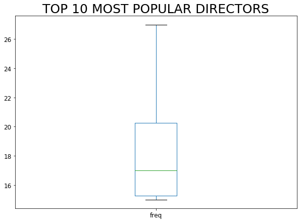

```python
#sorting values with highest frequency on the top
maxDirector=df.sort_values('freq',ascending=False)
maxDirector=maxDirector.drop_duplicates('director',keep='first')
#segregating top 10 values
maxDirectDF=maxDirector[0:10]
#plotting graph
maxDirectDF.plot(x='director', y='freq', kind='box',figsize=(10,7),legend=True, fontsize=12)
mpl.title('TOP 10 MOST POPULAR DIRECTORS',fontsize=25)
mpl.show()
```

> The above graph is a box plot of the 10 topmost directors . In order to find the topmost directors the director column is grouped and the number of time each comes in the dataframe is calculated. A frequency column is generated and the data about the number of times director has done movie is stored in that.

### Research Question 4 : which movie has the highest and lowest runtime?

```python
#finding index of highest runtime row
indexmaxrun=df['runtime'].idxmax()
#displaying title corrusponding to the index
dfObjrun = pd.DataFrame(df, columns = ['original_title','runtime'], index=[indexmaxrun])
print('Movie with highest runtime:')
dfObjrun
```

```
Movie with highest runtime:
```

|  | original_title | runtime |
| --- | --- | --- |
| 2107 | Carlos | 338.0 |

```python
#finding index of lowest runtime row
indexminrun=df['runtime'].idxmin()
#displaying title corrusponding to the index
dfObjminrun = pd.DataFrame(df,columns=['original_title','runtime'],index=[indexminrun])
print('Movie with lowest runtime:')
dfObjminrun
```

```
Movie with lowest runtime:
```

|  | original_title | runtime |
| --- | --- | --- |
| 5162 | Kid's Story | 15.0 |

[figure not shown]

```python
#sorting values with highest runtime on the top
maxRun=df.sort_values(by=['runtime'])
#segregating top 10 values
maxRunDF=maxRun[0:10]
#plotting graph
maxRunDF.plot(x='original_title', y='runtime', kind='line',figsize=(10,7),legend=True, fontsize=12)
mpl.xlabel('Movie Titles',fontsize=15)
mpl.ylabel('Runtime',fontsize=15)
mpl.title('TOP 10 MOVIES WITH HIGHEST RUNTIME',fontsize=25)
mpl.show()
```

### Research question 5: What is the average popularity rate in each year?

```python
#grouping the values based on release year
grouped = df.groupby('release_year')
```

```python
#printing the group
for name,group in grouped:
    meanpop=df['popularity'].mean()
    print(name)
    print(meanpop)
```

```
1960
1.19293290543
1961
1.19293290543
1962
1.19293290543
1963
1.19293290543
1964
1.19293290543
1965
1.19293290543
1966
1.19293290543
1967
1.19293290543
1968
1.19293290543
1969
1.19293290543
1970
1.19293290543
1971
1.19293290543
1972
1.19293290543
1973
1.19293290543
1974
1.19293290543
1975
1.19293290543
1976
1.19293290543
1977
1.19293290543
1978
1.19293290543
1979
1.19293290543
```

[output cut: 57 more lines]

```
1.19293290543
2009
1.19293290543
2010
1.19293290543
2011
1.19293290543
2012
1.19293290543
2013
1.19293290543
2014
1.19293290543
2015
1.19293290543
```

```python
#creating dictinary to store year and avg popularity
av_pop={}
for name,group in grouped:
    meanpop=group['popularity'].mean()
    av_pop[name]=meanpop
#converting dictionary to dataframe
popDf=pd.DataFrame.from_dict(av_pop,orient='index')
popDf.reset_index(level=0, inplace=True)
popDf.columns = ['year','average_popularity']
popDf.head(10)
```

|  | year | average_popularity |
| --- | --- | --- |
| 0 | 1960 | 1.324513 |
| 1 | 1961 | 0.787718 |
| 2 | 1962 | 0.983485 |
| 3 | 1963 | 1.040612 |
| 4 | 1964 | 1.377790 |
| 5 | 1965 | 1.054877 |
| 6 | 1966 | 0.395168 |
| 7 | 1967 | 0.953848 |
| 8 | 1968 | 0.913463 |
| 9 | 1969 | 1.152940 |

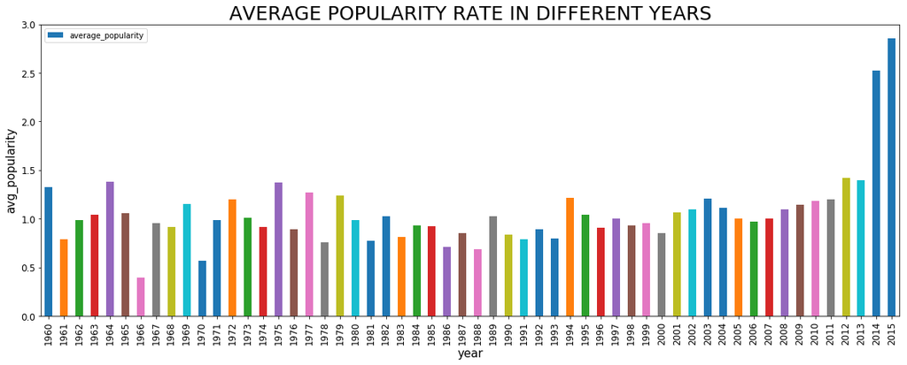

```python
#plotting the graph
popDf.plot(x='year', y='average_popularity', kind='bar',figsize=(20,7),legend=True, fontsize=12)
mpl.xlabel('year',fontsize=15)
mpl.ylabel('avg_popularity',fontsize=15)
mpl.title('AVERAGE POPULARITY RATE IN DIFFERENT YEARS',fontsize=25)
mpl.show()
```

> The above bar graph shows the average popularity among different years.For this we group the data based on release year. Then a dictionary is created where the key is the year and values is average popularity of that year.The dictionary is then converted to data frame which is then used to plot the above graph.

## Conclusions

- Avatar is the movie with highest revenue
- Shatter Glass is the lowest revenue movie
- The movie with the highest budget is The Warrior's Way
- The movie with the lowest budget is Lost & Found
- Steven Spielberg is the most popular director
- Carlos has highest runtime
- Kid's Story has lowest runtime
- Year 2015 has highest poularity rate

## Limitations

- It's not 100 percent guaranteed solution and this formula may or may not work, But it shows us that we have high probability of making high profits if we have similar characteristics as such. If we release a movie with these characteristics, it may or maynot be a hit
- During cleaning i dropped the rows which had budget and revenue equal to 0 .I converted them to null and dropped them. But it could have been done more effectively.we could have used internet to find the missing values. that would have given more accurate results.

## Submitting your Project

```python
from subprocess import call
call(['python', '-m', 'nbconvert', 'Investigate_a_Dataset.ipynb'])
```

```
0
```